## 0.1 load data

```r
data_filtered <- read.delim("FinalReport_ori.txt", skip=8, header=T, sep = "\t", comment.char = "", fill = TRUE, stringsAsFactors = F) %>%
  select(PROBE_ID, contains("AVG_Signal"), contains("Detection.Pval"))

# gene_symbol_new <- read.delim("official_gene_names_non_alt_loci_set.txt", stringsAsFactors = F) %>%
#   select(symbol, prev_symbol, alias_symbol) %>%
#   filter(prev_symbol != "" | alias_symbol != "") %>%
#   separate(col = prev_symbol, into = paste0("new", 1:20), sep = "\\|") %>%
#   gather(key = gene_name, value = TargetID, - symbol) %>%
#   select(-gene_name, gene_name = symbol) %>%
#   filter(!is.na(TargetID)) %>%
#   arrange(gene_name)

# load ensembl genes

# ensembl_genes <- read.table("mm10_genes.gtf", sep = "\t") %>%
#   select(chr = V1, start = V4, end = V5, strand = V7, V9) %>%
#   separate(V9, into = paste0("new", 1:7), remove = T, sep = "; ") %>%
#   mutate(chr = paste0("chr", chr),
#          ensembl_id = gsub("gene_id ", "", new1),
#          gene_name = gsub("gene_name ", "", new3) %>% toupper()) %>%
#   select(chr, start, end, strand, ensembl_id, gene_name) %>%
#   makeGRangesFromDataFrame(keep.extra.columns = T)

# load ensembl to refseq translator

#
# mart<- useMart("ensembl", dataset = "mmusculus_gene_ensembl")
# mart_data <- getBM(attributes=c("refseq_mrna_predicted", "refseq_mrna", "external_gene_name", "illumina_mouseref_8_v2"), filters = "illumina_mouseref_8_v2", values = data_filtered$PROBE_ID, mart=mart)
# saveRDS(mart_data, file = "mart_data.rds")

mart_data <- readRDS(file = "mart_data.rds")

predicted_refseq_to_real <- mart_data %>% filter(illumina_mouseref_8_v2 != "") %>%
  mutate(refseq_mrna = ifelse(refseq_mrna == "", refseq_mrna_predicted, refseq_mrna)) %>%
  filter(refseq_mrna != "", grepl("NM", refseq_mrna)) %>%
  select(-refseq_mrna_predicted) %>% unique() %>%
  group_by(illumina_mouseref_8_v2) %>% arrange(refseq_mrna) %>% do(head(., 1))

probe_names <- read.table("refseq_to_genename.txt", stringsAsFactors = F)

gene_info <- read.delim("FinalReport_ori.txt", skip=8, header=T, sep = "\t", fill = TRUE, stringsAsFactors = F) %>%
  select(TargetID, PROBE_ID, ACCESSION, SYMBOL) %>% tbl_df() %>%
  mutate(REFSEQ_ID = gsub("\\..*", "", ACCESSION)) %>%
  left_join(predicted_refseq_to_real, by = c("PROBE_ID" = "illumina_mouseref_8_v2")) %>%
  mutate(refseq = ifelse(!is.na(refseq_mrna), refseq_mrna, REFSEQ_ID),
         gene_name = ifelse(!is.na(external_gene_name) & external_gene_name != SYMBOL, external_gene_name, SYMBOL)) %>%
  select(-contains("refseq_"), -SYMBOL, -ACCESSION, -external_gene_name) %>%
  unique() %>%
  left_join(., probe_names, by = c("refseq" = "V1")) %>%
  mutate(V2 = ifelse(is.na(V2), gene_name, V2),
         gene_name = ifelse(V2 != gene_name, V2, gene_name)) %>%
  select(-V2, -TargetID) %>% unique()

sample_info <- read.csv("Sample info.csv", stringsAsFactors = F) %>%
  mutate(description = gsub("transfected MEF cultured in", "", description))
```

- remove genes that are only expressed in 1 or less sample

```r
genes_to_keep <- data_filtered %>%
  select(PROBE_ID, contains("Pval")) %>%
  gather(key = sample, value = pval, -PROBE_ID) %>%
  group_by(PROBE_ID) %>%
  summarize(samples_detected = sum(pval<0.05)) %>%
  filter(samples_detected >= 2)

data_filtered_expressed <- data_filtered %>%
  select(PROBE_ID, contains("Signal")) %>%
  setnames(colnames(.)[-1], as.character(sample_info$Sample))

probe_names <- data_filtered_expressed$PROBE_ID

data_filtered_matrix <- data_filtered_expressed %>%
  select(-PROBE_ID) %>%
  data.matrix()

rownames(data_filtered_matrix) <- probe_names

# data_filtered_matrix[x>0.01] <- median(data_filtered_matrix[x>0.01], na.rm = T)

data_filtered_matrix_expressed <- data_filtered_matrix %>%
  subset(rownames(.) %in% genes_to_keep$PROBE_ID)
```

## 0.2 Check distribution of gene expression

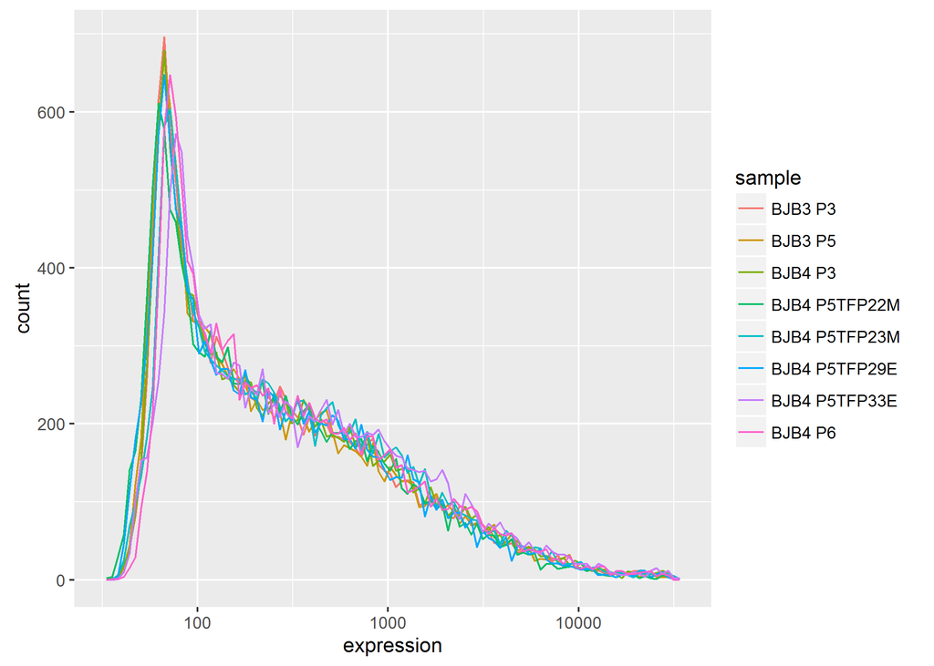

```r
data_filtered_matrix_expressed %>%
  as.data.frame() %>%
  # select(-contains("Pval")) %>%
  gather(key = sample, value = expression) %>%
  mutate(expression = as.numeric(expression)+1) %>%
  tbl_df() %>%
  ggplot(aes(expression, color = sample)) +
  geom_line(stat="bin", bins = 100) +
  scale_x_log10()
```

## 0.3 Quantile normalize

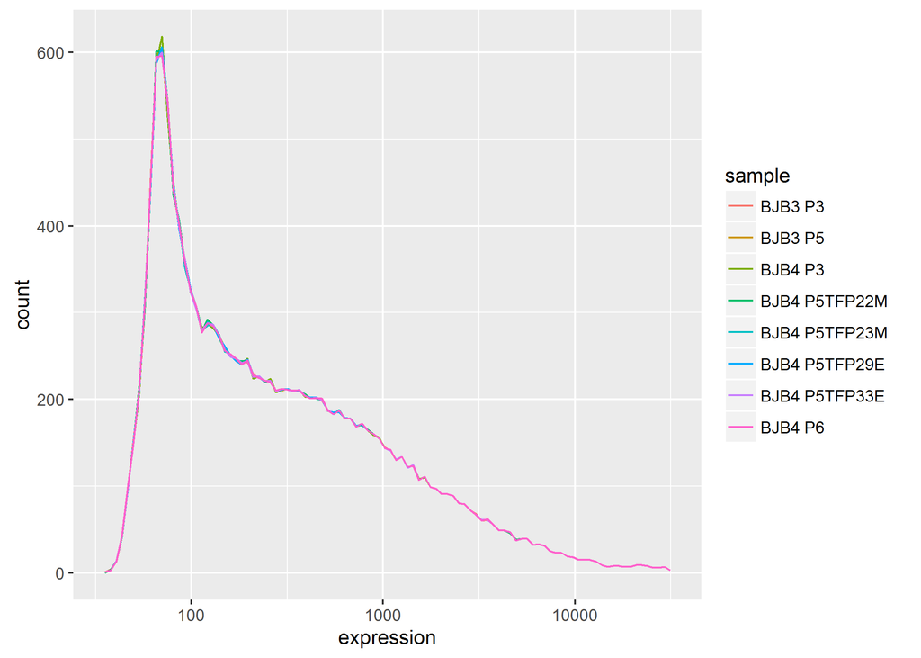

```r
data_filtered_matrix_expressed <- data_filtered_matrix_expressed %>%
  normalizeQuantiles()

data_filtered_matrix_expressed %>%
  as.data.frame() %>%
  # select(-contains("Pval")) %>%
  gather(key = sample, value = expression) %>%
  mutate(expression = as.numeric(expression)+1) %>%
  tbl_df() %>%
  ggplot(aes(expression, color = sample)) +
  geom_line(stat="bin", bins = 100) +
  scale_x_log10()
```

## 0.4 Check global correlations

- spearman correlation

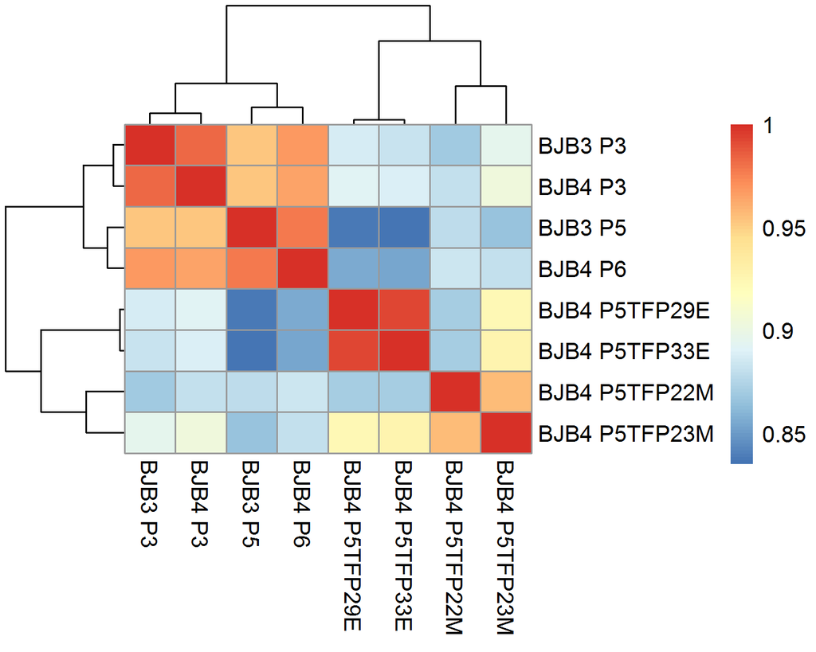

```r
cor(data_filtered_matrix_expressed, method = "spearman") %>%
  pheatmap()
```

- euclidean distance on log transformed expression

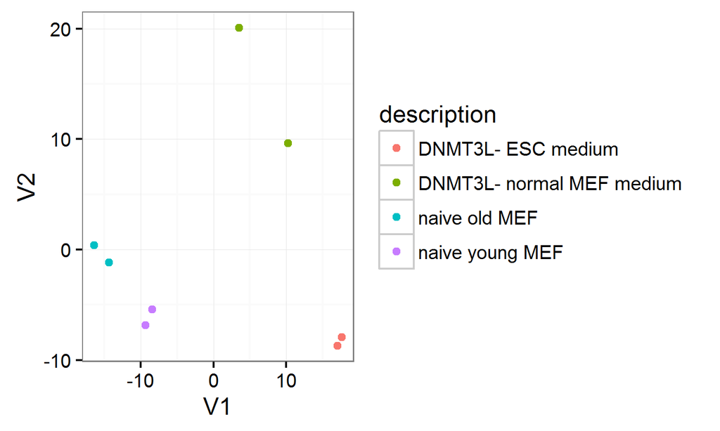

```r
cmdscale(dist(t(log10(data_filtered_matrix_expressed+1)))) %>%
  as.data.frame() %>%
  tibble::rownames_to_column("Sample") %>%
  inner_join(sample_info) %>%
  ggplot(aes(V1,V2, color = description)) +
  geom_point() +
  theme_bw()
```

## 0.5 Fit `Limma` model

```r
model_matrix <- model.matrix(~0 + sample_info$description)

colnames(model_matrix) <- c("DNMT3L_ESC", "DNMT3L_MEF", "old_MEF", "young_MEF")

limma_fit <- lmFit(log2(data_filtered_matrix_expressed), design = model_matrix)
```

## 0.6 Compare old vs young

```r
limma_contrast <- contrasts.fit(fit = limma_fit, contrasts = makeContrasts(old_MEF-young_MEF, levels = colnames(model_matrix))) %>% eBayes()

hits <- topTable(limma_contrast, number = Inf, p.value = 0.1)

gene_descriptions <- inner_join(gene_info, hits %>% rownames_to_column("PROBE_ID")) %>%
  mutate(change = ifelse(logFC > 0, "Higher in old", "Lower in old"))
```

- Plot results

Row-wise Z-score normalized log10(x+1) expression

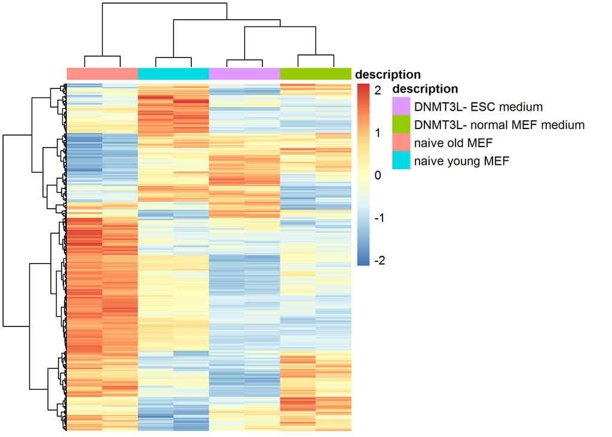

```r
anno_col <- sample_info %>%
  select(Sample, description) %>%
  tibble::column_to_rownames("Sample")

log10(data_filtered_matrix_expressed+1) %>%
  subset(rownames(.) %in% rownames(hits)) %>%
  pheatmap(scale="row", show_rownames=F, show_colnames=F, clustering_method = "ward.D2", annotation_col = anno_col)
```

## 0.7 Compare old vs treated

```r
limma_contrast <- contrasts.fit(fit = limma_fit, contrasts = makeContrasts(old_MEF-DNMT3L_MEF, levels = colnames(model_matrix))) %>% eBayes()

hits <- topTable(limma_contrast, number = Inf, p.value = 0.1, sort.by = "p")

gene_descriptions_old_treat <- inner_join(gene_info, hits %>%rownames_to_column("PROBE_ID")) %>%
  mutate(change = ifelse(logFC > 0, "Higher in old", "Lower in old"))
```

There are 5531 differentially expressed genes

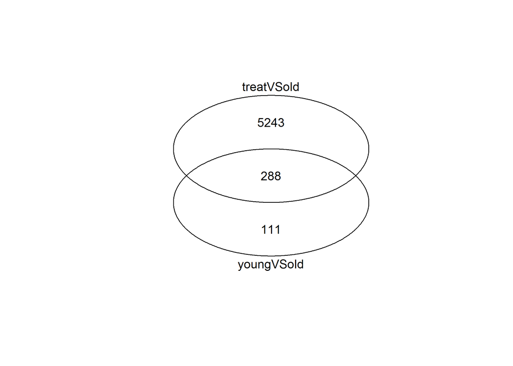

```r
x <- venn(list(
youngVSold=gene_descriptions$PROBE_ID,
treatVSold=gene_descriptions_old_treat$PROBE_ID
))
```

```r
overlap_pval <- sum(dhyper(
  x = length(attr(x, "intersections")[[3]]):length(gene_descriptions$PROBE_ID),
  m = length(gene_descriptions_old_treat$PROBE_ID),
  n = nrow(data_filtered_expressed) - length(gene_descriptions_old_treat$PROBE_ID),
  k = length(gene_descriptions$PROBE_ID)
)) %>% signif(3)
```

The hypergeometric pvalue of this overlap is 1.8110^{-105}

## 0.8 analyze genes thare are different in both comparisons

```r
overlap_genes <- attr(x, "intersections")[[3]]

tabled <- left_join(
  gene_descriptions %>% filter(PROBE_ID %in% overlap_genes) %>%
  select(PROBE_ID, youngVSold = change),
  gene_descriptions_old_treat %>% filter(PROBE_ID %in% overlap_genes) %>%
  select(PROBE_ID, treatVSold = change)
)
```

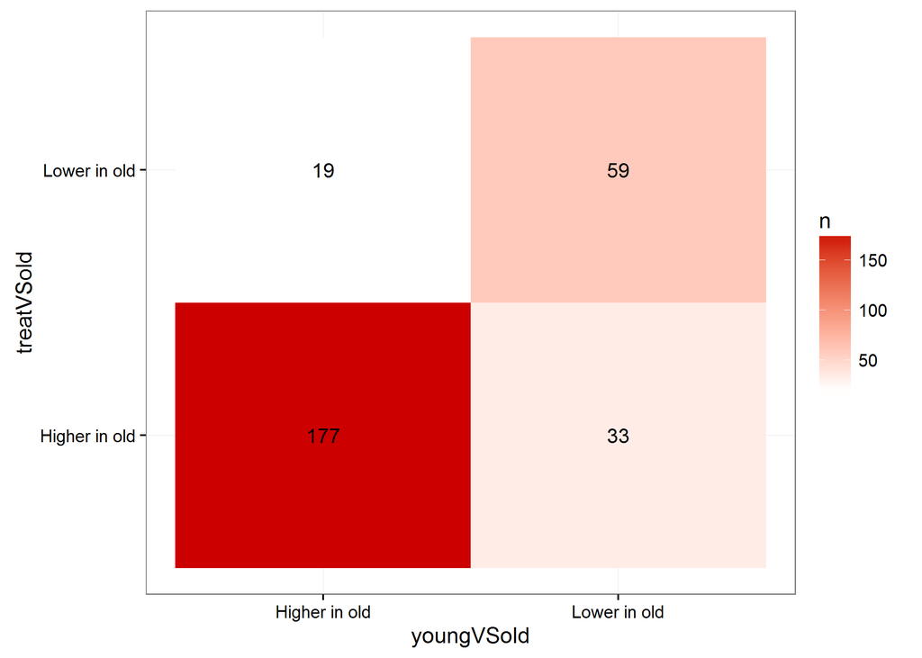

```r
tabled %>% group_by(youngVSold, treatVSold) %>% tally %>%
  ggplot(aes(youngVSold, treatVSold, label = n)) +
  geom_tile(aes(fill = n)) +
  geom_text() +
  scale_fill_continuous(low = "white", high = "red3") +
  theme_bw()
```

```r
concordant_direction <- tabled %>%
  filter(youngVSold == treatVSold)
```

81.9% of hits are concordant

- check some individual genes

```r
gene_set_query <- concordant_direction %>%
  # select(PROBE_ID) %>%
  left_join(gene_info) %>%
  as.data.frame() %>%
  select(-PROBE_ID) %>%
  unique()
final_matrix_long <- data_filtered_matrix %>% as.data.frame %>%
  rownames_to_column("PROBE_ID") %>%
  gather(key = "Sample", value = expr, -PROBE_ID) %>%
  left_join(., gene_info) %>%
  left_join(., sample_info)
```

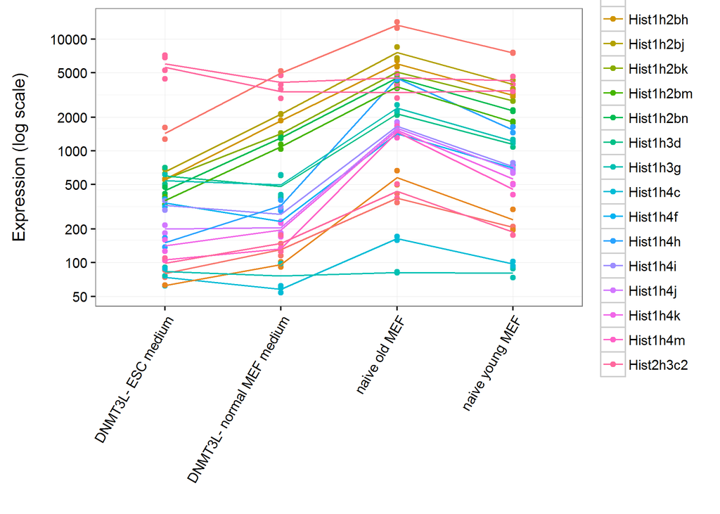

```r
check_gene <- function(gene, diff = TRUE) {
  if (diff) {
    final_matrix_long <- final_matrix_long %>%
      subset(gene_name %in% gene_set_query$gene_name)
  }
  final_matrix_long %>%
    filter(gene_name %in% gene) %>%
    ggplot(aes(description, expr)) +
    geom_point(aes(color = gene_name)) +
    # facet_wrap(~gene_name, ncol = 1, scales = "free_y") +
    stat_summary(fun.y=mean, geom="line", aes(group = PROBE_ID, color = gene_name)) +
    theme_bw() +
    # ggtitle(paste(gene, collapse = ", ")) +
    scale_y_log10(breaks=c(10^seq(1,3,1) * 5, 10^seq(1,3,1)*2, 10^seq(1,3,1)*10)) +
    ylab("Expression (log scale)\n") +
    xlab("") +
    theme(axis.text.x = element_text(angle = 60, hjust = 1))
}

check_gene(gene = grep("Hist", gene_set_query$gene_name, value = T), diff =T)
```

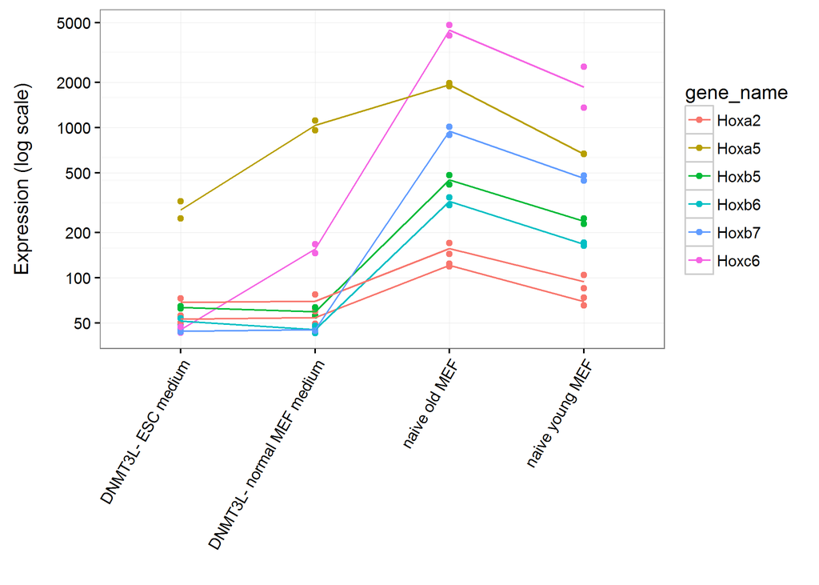

```r
check_gene(gene = grep("Hox", gene_info$gene_name, value = T), diff = T)
```

```r
write.table(gene_info$refseq, "gene_set_background.txt", col.names = F, row.names = F, quote = F)

gene_set_query %>%
  filter(treatVSold == "Higher in old") %>%
  select(gene_name) %>%
  write.table("gene_set_foreground_upinold.txt", col.names = F, row.names = F, quote = F)

gene_set_query %>%
  filter(treatVSold != "Higher in old") %>%
  select(gene_name) %>%
  write.table("gene_set_foreground_downinold.txt", col.names = F, row.names = F, quote = F)
```

- browse through gene list

```r
DT::datatable(gene_set_query)
```

|  | youngVSold | treatVSold | refseq | gene_name |
| --- | --- | --- | --- | --- |
| 1 | Lower in old | Lower in old | NM_178066 | Tmem198b |
| 2 | Higher in old | Higher in old | NM_026805 | Svop |
| 3 | Lower in old | Lower in old | NM_026894 | Tamm41 |
| 4 | Higher in old | Higher in old | NM_029674 | Got1l1 |
| 5 | Higher in old | Higher in old | NM_001177945 | Aamdc |
| 6 | Lower in old | Lower in old | NM_026509 | Murc |
| 7 | Higher in old | Higher in old | NM_001205236 | Arhgap27 |
| 8 | Higher in old | Higher in old | NM_173744 | Tdrp |
| 9 | Higher in old | Higher in old | NM_133778 | Fam131a |
| 10 | Higher in old | Higher in old | NM_028713 | Rftn2 |

[output cut: 213 more lines]

## 0.9 Pathway analysis

- Load MsigDB

```r
msigdb <- readLines("ReactomePathways.gmt") %>% str_split("\n")

msigdb <- lapply(msigdb, function(x) str_split(x, "\t") %>% unlist)

msigdb_names <- lapply(msigdb, function(x) x[1]) %>% unlist

# msigdb_species <- lapply(msigdb, function(x) x[2]) %>% unlist

background <- gene_info$gene_name %>% toupper() %>% unique()
# background <- background  %>% subset(!grepl("HIST", .))

msigdb_pruned <- lapply(msigdb, function(x) subset(x, x %in% background))

universe <- length(background)

names(msigdb_pruned) <- msigdb_names

# msigdb_pruned <- msigdb_pruned[lapply(msigdb_pruned, length) >= 5]

# msigdb_pruned <- msigdb_pruned[!grepl("GSE|CANCER|_UP|_DN", names(msigdb_pruned))]
```

- set up hypergeometric test

```r
geometric_test <- function(db, query, filter_hist = FALSE) {

  query <- toupper(query)

  if (filter_hist) {
    query <- query %>% subset(!grepl("HIST", .))
    db <- lapply(db, function(x) subset(x, !grepl("HIST", x)))
  }

  n_hits <- sum(unique(query) %in% db)
  n_true <- length(db)
  n_false <- universe - length(db)
  n_tries <- length(unique(query))

  overlap_pval <- sum(dhyper(
    x = n_hits:n_tries,
    m = n_true,
    n = n_false,
    k = n_tries
  )) %>% signif(3)

  data.frame(
    query_length = n_tries,
    gene_set_length = n_true,
    overlap = n_hits,
    pval = overlap_pval
  )
}

master_test <- function(query, db = msigdb_pruned, ...) {
  lapply(db, function(x) geometric_test(db = x, query = query, ...)) %>% rbindlist() %>%
  mutate(fdr = p.adjust(pval, method = "fdr"),
         log_fdr = -log10(fdr),
         gene_set = names(db),
         gene_set = gsub("_", " ", gene_set)) %>%
    arrange(pval)
}
```

- test the gene sets

```r
higher_in_old <- gene_set_query  %>%
  filter(youngVSold == "Higher in old") %>%
  .$gene_name

higher_in_old_pathways <- higher_in_old %>%
  master_test()

higher_in_young <- gene_set_query  %>%
  filter(youngVSold != "Higher in old") %>%
  .$gene_name

higher_in_young_pathways <- higher_in_young %>%
  master_test()
```

## 0.10 Visualize Pathways

Genes expressed in

### 0.10.1 Higher in old

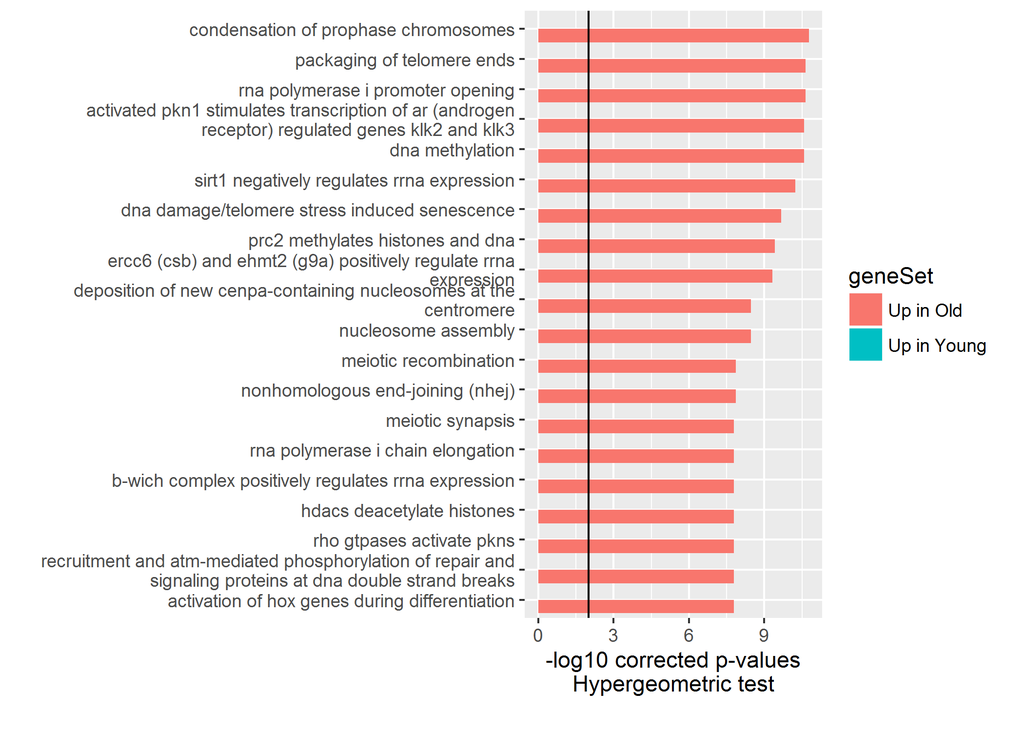

```r
plot_enriched_pathways <- function(pathway_df, n_terms = 20, old_df = higher_in_old_pathways, young_df = higher_in_young_pathways) {
  # pathway_df <- higher_in_old_pathways
  hits <- pathway_df %>%
    filter(fdr < 0.1) %>%
    arrange(fdr) %>%
    head(n_terms) %>% .$gene_set

  if(length(hits) == 0) return("No hits found")

  old <- old_df %>%
    subset(gene_set %in% hits) %>%
    mutate(geneSet = "Up in Old")

  young <- young_df %>%
    subset(gene_set %in% hits) %>%
    mutate(geneSet = "Up in Young")

  rbind(old, young) %>%
    mutate(gene_set = tolower(gene_set),
           gene_set = factor(gene_set, levels = rev(tolower(hits)))) %>%
    ggplot(aes((gene_set), -log(fdr), fill = geneSet)) +
    geom_bar(stat="identity", position = "dodge") +
    geom_hline(yintercept = -log10(0.01)) +
    # theme(axis.text.x = element_text(angle = 60, hjust = 1)) +
    xlab("") +
    coord_flip()+
    ylab("-log10 corrected p-values\nHypergeometric test\n") +
    scale_x_discrete(labels = function(x) str_wrap(x, width = 60))
}

plot_enriched_pathways(pathway_df = higher_in_old_pathways)
```

*trim 28

### 0.10.2 Higher in young

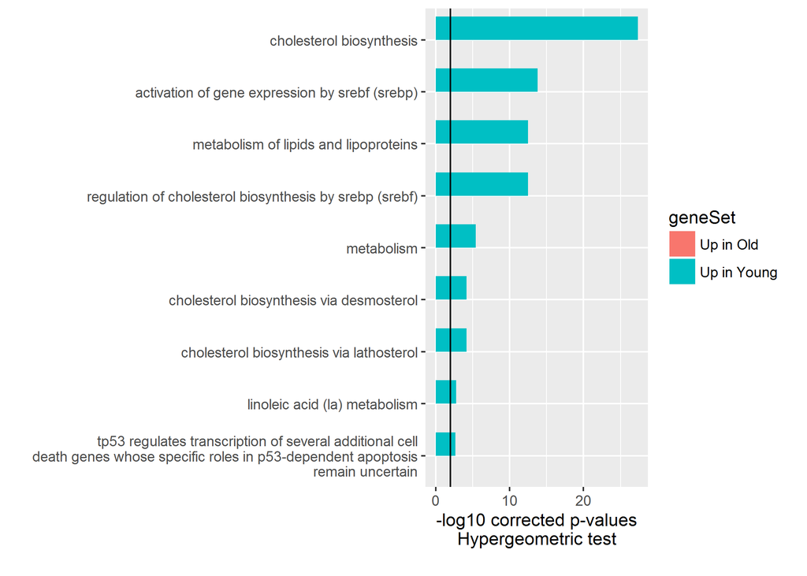

```r
plot_enriched_pathways(pathway_df = higher_in_young_pathways)
```

### 0.10.3 Manual check pathway

```r
check_pathway <- function(gene_set_name, db = msigdb_pruned, filter_hist = TRUE) {
  gene_set <- db[[gene_set_name]]
  higherInOld <- gene_set_query %>% filter(youngVSold == "Higher in old") %>% .$gene_name %>% toupper %>% .[. %in% gene_set]
  higherInYoung <- gene_set_query %>% filter(youngVSold != "Higher in old") %>% .$gene_name %>% toupper %>% .[. %in% gene_set]
  if (filter_hist) {
    higherInOld <- higherInOld %>% .[!grepl("HIST", .)]
    higherInYoung <- higherInYoung %>% .[!grepl("HIST", .)]
  }
  y <- list(gene_set_name = gene_set_name, higherInOld = higherInOld, higherInYoung = higherInYoung, all= gene_set)
  names(y)[4] <- gene_set_name
  return(y)
}

check_pathway(higher_in_young_pathways$gene_set[1])[1:3]
```

```
## $gene_set_name
## [1] "Cholesterol biosynthesis"
##
## $higherInOld
## character(0)
##
## $higherInYoung
## [1] "ACAT2"  "DHCR24" "DHCR7"  "FDPS"   "LSS"    "PMVK"   "MSMO1"  "SQLE"
```

http://www.mousephenotype.org/data/genes/MGI:87871#section-associations http://amp.pharm.mssm.edu/Enrichr/enrich http://journals.plos.org/plosone/article?id=10.1371/journal.pone.0057172

## 0.11 ChEA enrichment

Transcription factor regulated genes, as determined by ChIP-seq or ChIP-ChIP

Data downloaded from http://amp.pharm.mssm.edu/Enrichr/#stats

```r
db <- readLines("ChEA_2015.txt") %>% str_split("\n") %>% lapply(function(x) str_split(x, "\t") %>% unlist %>% gsub("\\,1\\.0", "", .))

cheaDB_names <- lapply(db, function(x) x[1]) %>% unlist

db <- lapply(db, function(x) subset(x, x %in% background))

universe <- background %>% length()

names(db) <- cheaDB_names

cheaDB <- db %>% .[grepl("Mouse", names(.))]
```

```r
chea_TF_results <- lapply(list(higher_in_old = higher_in_old, higher_in_young = higher_in_young), FUN = master_test, db = cheaDB)
```

### 0.11.1 Old

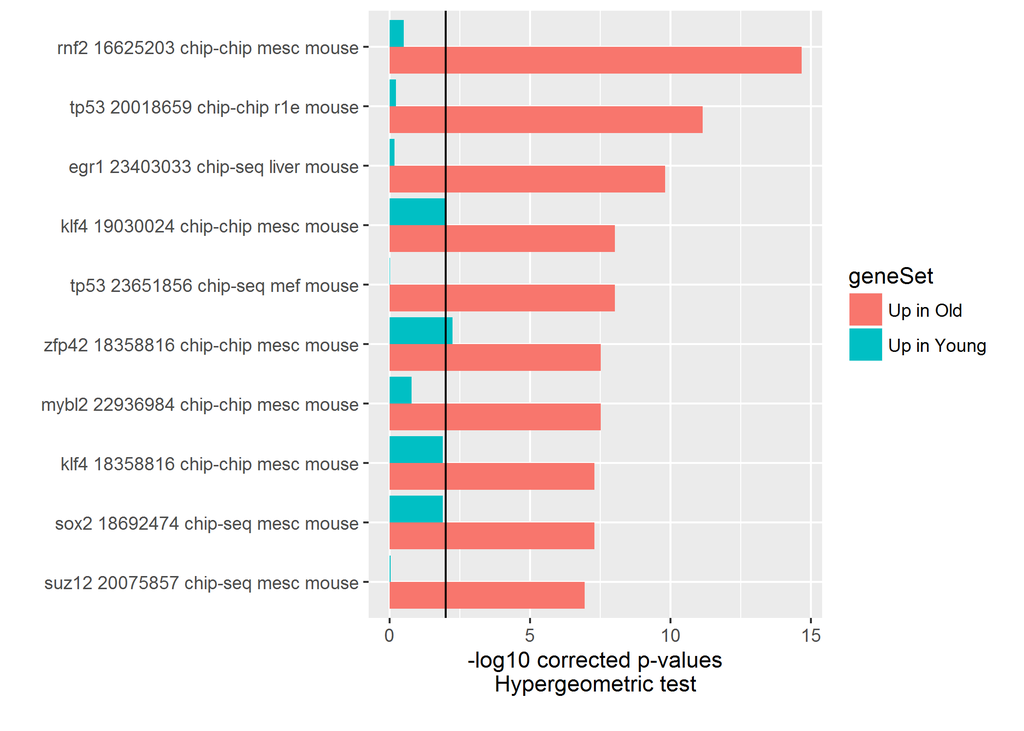

```r
plot_enriched_pathways(pathway_df = chea_TF_results[[1]], n_terms = 10, old_df = chea_TF_results[[1]], young_df = chea_TF_results[[2]])
```

### 0.11.2 young

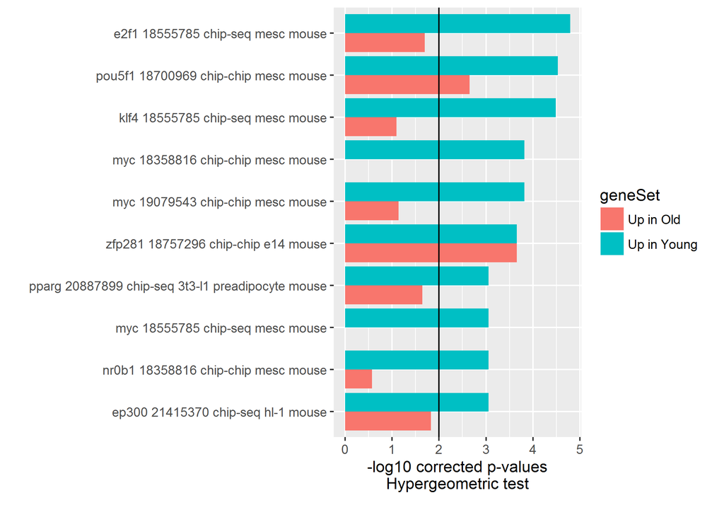

```r
plot_enriched_pathways(pathway_df = chea_TF_results[[2]], n_terms = 10, old_df = chea_TF_results[[1]], young_df = chea_TF_results[[2]])
```

### 0.11.3 Manual check pathway

```r
check_pathway(gene_set_name = grep("KLF4_19", names(cheaDB), value = T)[1], db = cheaDB)[1:3]
```

```
## $gene_set_name
## [1] "KLF4_19030024_ChIP-ChIP_MESC_Mouse"
##
## $higherInOld
##  [1] "GOT1L1"  "ALDH3A2" "BDNF"    "CCND1"   "DPYSL4"  "DMTN"    "HOXA2"
##  [8] "HOXA5"   "HOXB5"   "HOXB6"   "IGFBP2"  "JAM2"    "MSX2"    "NR2F1"
## [15] "PCDH17"  "PRLR"    "SIM2"    "STMN2"
##
## $higherInYoung
## [1] "AKAP12" "BIRC5"  "ELOVL6" "FDPS"   "HMGN2"  "NID2"   "SORCS2" "SQLE"
## [9] "TRIM28"
```

## 0.12 Encode histone enrichment

Data downloaded from http://amp.pharm.mssm.edu/Enrichr/#stats

```r
db <- readLines("ENCODE_Histone_Modifications_2015.txt") %>% str_split("\n") %>% lapply(function(x) str_split(x, "\t") %>% unlist)

names <- lapply(db, function(x) x[1]) %>% unlist

db <- lapply(db, function(x) subset(x, x %in% background))

names(db) <- names

encode <- db %>% .[grepl("_mm9", names(.))]
```

### 0.12.1 Old

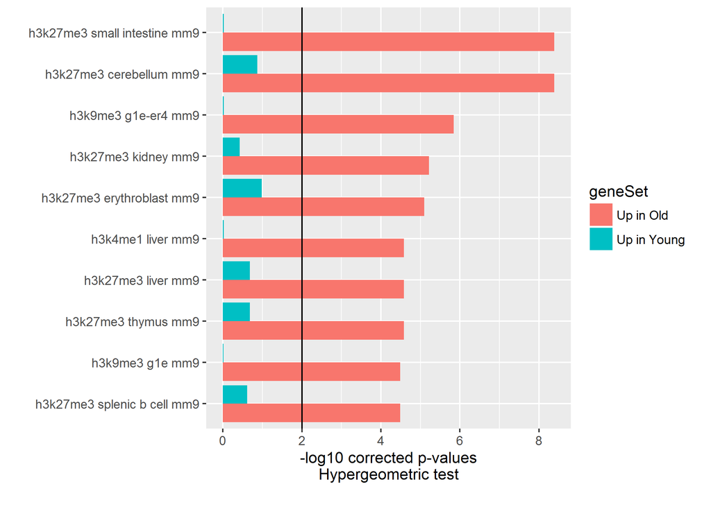

```r
encode_histones <- lapply(list(higher_in_old = higher_in_old, higher_in_young = higher_in_young), FUN = master_test, db = encode)

plot_enriched_pathways(pathway_df = encode_histones[[1]], n_terms = 10, old_df = encode_histones[[1]], young_df = encode_histones[[2]])
```

### 0.12.2 young

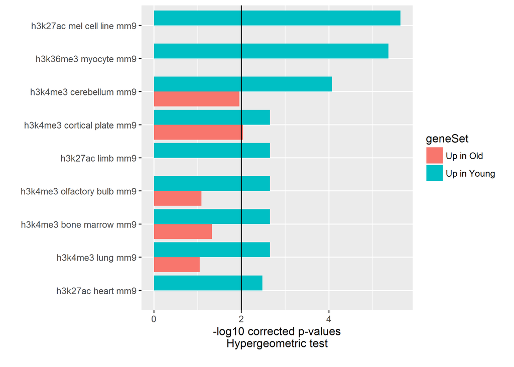

```r
plot_enriched_pathways(pathway_df = encode_histones[[2]], n_terms = 10, old_df = encode_histones[[1]], young_df = encode_histones[[2]])
```

## 0.13 Homer results

### 0.13.1 old

[interactive chart not shown]

### 0.13.2 young

[interactive chart not shown]

## 0.14 Model

Sensense is regulated by rnf2, a critical component of PRC1. In old mice, senescent genes normally silenced by PRC1 are reactivated, and cause the cell to sensence. Indeed, these genes are typically associated with repressive marks across a wide variet of ENCODE cell lines.

However, pulse of DNMT3L causes these senescence genes to be re-silenced, and allows to cells to exit senenscence. Interestingly, this silencing is stable even in the abscence of DNMT3L.

### 0.14.1 Previous literature

- Cdkn2a

Interestingly, PK^INK4a (Cdkn2a) is previously implicated as a [master regulator of senescence](http://www.nature.com/nature/journal/v506/n7488/full/nature13013.html) (ref 19-22 within). In our data, it appears DNMT3L does not silence this gene, even though PRC1 is supposed to supress it (ref 26-28 within).

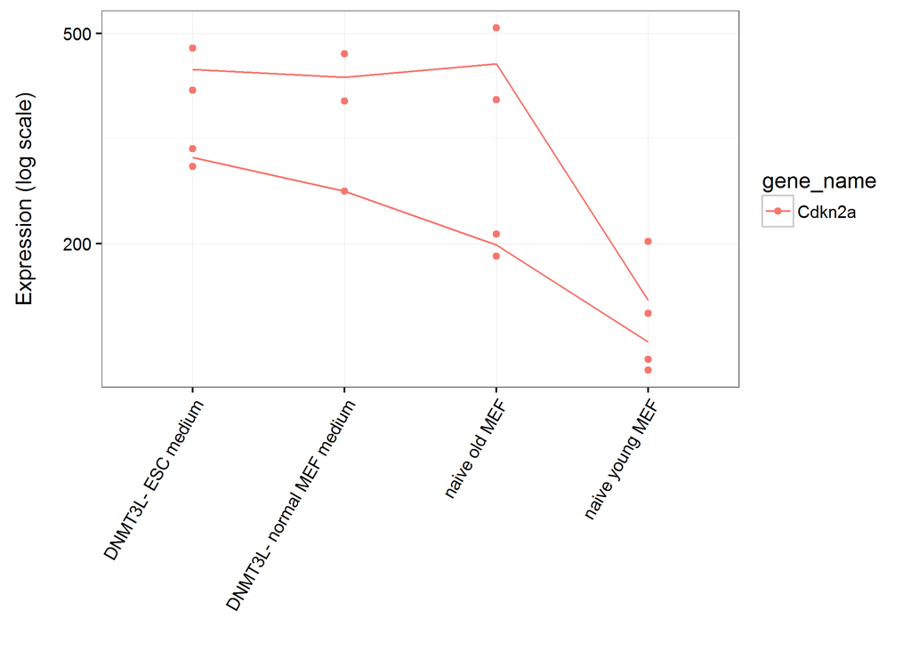

```r
check_gene(gene = grep("Cdkn2a$", gene_info$gene_name, value = T), diff = F)
```

- Rb1 and p53

Supposedly, *Rb1* and *p53* are the two “master regulators” of senescence, as stated in [this review](http://www.nature.com/onc/journal/v30/n26/full/onc201134a.html)

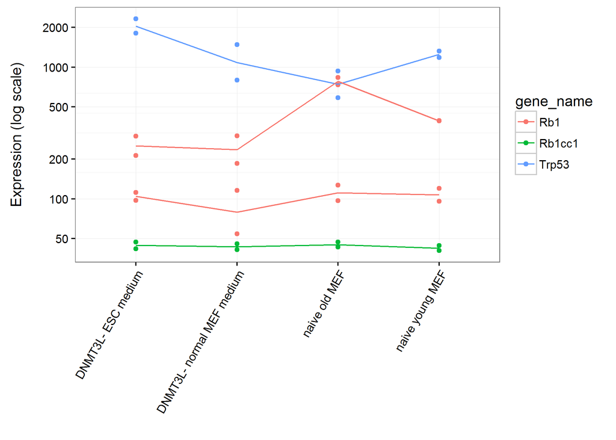

```r
check_gene(gene = grep("Rb[0-9]|Trp53$", gene_info$gene_name, value = T), diff = F)
```

Interesting, neither gene seem involved in the senescnece observed here. p53’s notable target genes, Bax, Apaf, Mdm2, and p21 (aka Cdkn1a), seem to be changed in DNMT3L pulse, but not during young MEF

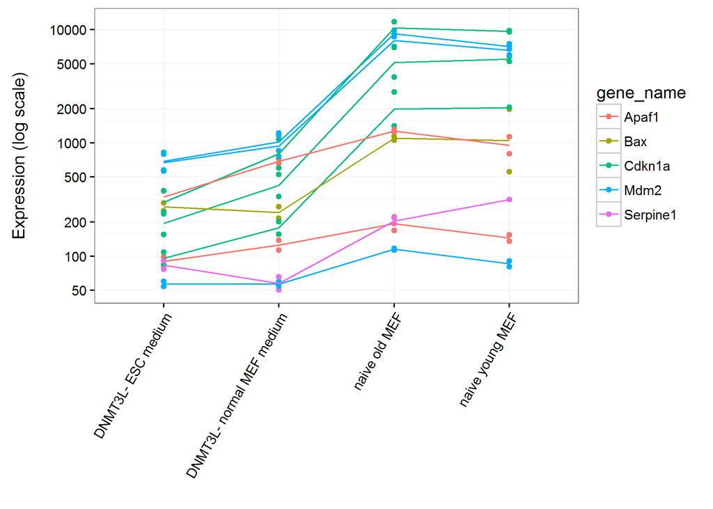

```r
check_gene(gene = grep("Bax|Apaf|Mdm2|Cdkn1a|Serpine1", gene_info$gene_name, value = T), diff = F)
```

Rb1 seems to supress E2F target genes via Cdkn2a [ref](http://www.sciencedirect.com/science/article/pii/S009286740300401X). Since Cdkn2a doesn’t seem to be changed during DNMT3L induction, Rb1 is probably not involved. Interesting, because Cdkn2a is a PRC1 target [ref](http://www.nature.com/onc/journal/v30/n26/full/onc201134a.html#Transcriptional-regulation-of-the-INK4A-ARF-locus), and I think PRC1 is involved… for some reason Cdkn2a escapes

- PRC1 is important for senescence

Becuase our study identified Rnf2 as a core regulator of our differentially expressed genes, and Rnf2 is a core member of PRC1 [genecards.com](http://www.genecards.org/cgi-bin/carddisp.pl?gene=RNF2)

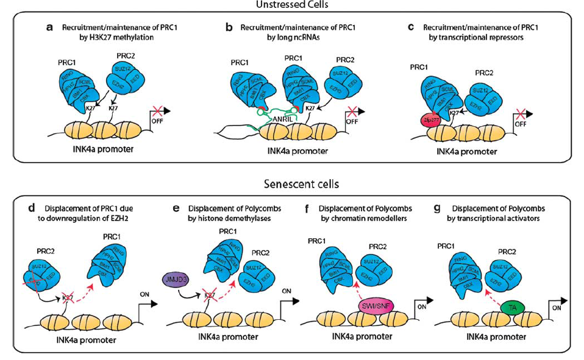

Bmi1 defecient MEFs senescence early by allowing Cdkn2a to activate [ref](http://www.nature.com/nature/journal/v397/n6715/full/397164a0.html). In our case, it seems expression of **Bmi1** increases upon DNMT3L induction. In addition, Cbx7, and Mel18 (Pcgf2) knockdown leads to cellular arrest, the same as Bmi1. But the data doesn’t show difference in expression, except maybe Cbx7 being upregulated.

Zfp277 is required for Bmi1 mediated senescence, such that Zfp277 knockout can’t be rescued with Bmi1

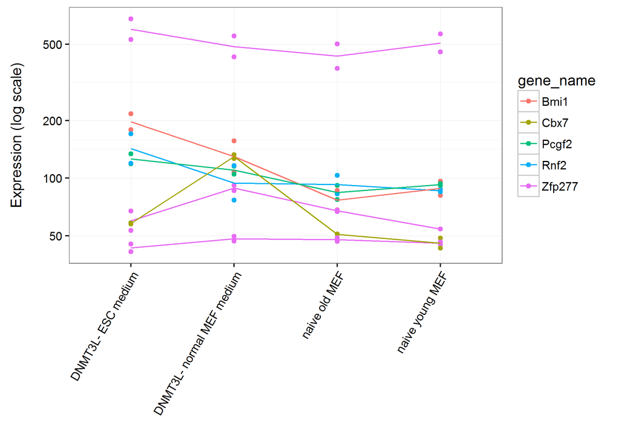

```r
check_gene(gene = grep("Rnf2$|Bmi|Cbx7|Pcgf2|Zfp277", gene_info$gene_name, value = T), diff = F)
```

- How does DNMT3L recruit PRC1 to senescence related genes?

Turns out H3K27me3 is required for PRC1 recruitment to this loci, and Ezh2 is responsible since PRC1 is recruited to sites of H3K27me3. Expression of Ezh2 is increased, but not statistically significant.

JMJD3 (aka Kdm6b) removes H3K27me3 and allows senescence to happen.

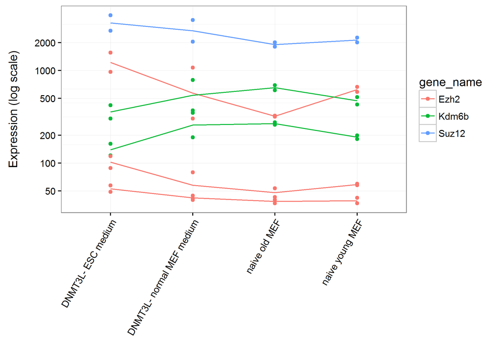

```r
check_gene(gene = grep("Ezh2|Kdm6b|Suz12", gene_info$gene_name, value = T), diff = F)
```

DNMT3L binds directly to Ezh2 and Suz12. ref. Apparently, DNMT3L kicks out other DNMTs and prevents methylation of the loci. **should bisulfite sequence this to check**. The paper also performed DNMT3L Chip-seq, so it should be possible to check.

As for HOX genes, looks like HOTAIR recruits PRC2 to the hox cluster [ref](http://www.ncbi.nlm.nih.gov/pubmed/17604720). Furthermore, knocking out DNMT3L’s binding domain causes HOX genes to increase expression (in spermatogonia) [ref](http://dx.doi.org/10.1016/j.celrep.2015.01.021). This explains why Hox is higher expressed in old, because it’s losing PRC2 repression.

Actually, looks like others cannot replicate the interaction between DNMT3L and EZH2 [ref](http://dx.doi.org/10.1016/j.celrep.2015.01.021). Yes interaction in ESC, no interaction in sperm. Wat.

## 0.15 End